# R Notebook

# Descripción del desafío.

Usted trabaja para una conocida aseguradora nacional al cual un Banco internacional le ha solicitado un presupuesto. Para ello su equipo debe entregar el precio base estimado de los seguros al crédito, el cual se ocupa como parámetro posteriormente para tarificar los distinto productos. El economista con el cual usted trabajada ha diseñado una fórmula para calcular este precio:

Precio base del seguro por persona= (3*(1+0.03+p)) UF Donde p corresponde al factor de penalización por riesgo y su fórmula es: p=(0.1* score de riesgo) Donde el score de riesgo debe ir entre 0 y 1, y debe reflejar qué tan probable es que un cliente caiga en mora (en general y con los datos de hoy, no para un momento particular) Se le ha encargado calcular este score a partir de los datos que han sido entregados por el Banco y presentar en una reunión de 15 minutos sus resultados a la gerencia. (esta será realizada por Skype y “la gerencia” será el reclutador técnico).

Consideraciones entregadas por el negocio:

- Es 5 veces peor clasificar un cliente como bueno cuando es malo, que malo cuando es bueno
- Las tarifas telefónicas son altas en el país de donde provienen los clientes de este banco
- Hay una alta tasa de migración en el país de donde provienen los clientes de este banco

# Resumen.

El siguiente resumen tiene como finalidad mostrar análisis y detalle de los pasos realizados en la solución del problema. El desafio se encuentra establecido en los márgenes de un modelo de riesgo, para ello ha sido utilizado el modelo de regresión logística con la metodología de scorecard.

A continuación se indican los pasos en la resolución del problema:

1. Análisis descriptivo univariado.
2. Análisis descriptivo bivariado respecto a la variable “Clasificación actual”.
3. Binning de variables utilizando WoEs.
4. Modificación cortes óptimos para los WoEs.
5. Ranking information value.
6. Evaluación modelo completo.
7. Significancia de coeficientes del modelo.
8. Reducción de variables.
9. Análisis de correlaciones y VIF de variables predictoras.
10. Validar distribución del score y bad rate.
11. Cálculo de precio base con análisis de distribución.

# Descriptivos univariados

### Variable 2: Duración en meses

```r
#Variables continuas#
describe(data_desafio_seguros$var_2)
```

```
data_desafio_seguros$var_2
       n  missing distinct     Info     Mean      Gmd      .05      .10      .25      .50      .75      .90      .95
     900        0       32    0.985    21.09       13        6        9       12       18       24       36       48

lowest :  4  6  7  8  9, highest: 47 48 54 60 72
```

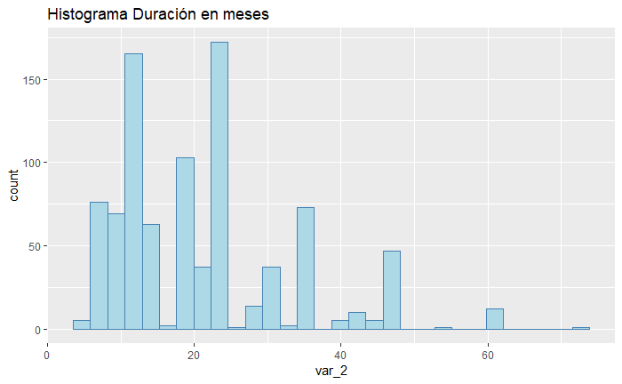

```r
ggplot(data_desafio_seguros, aes(x=var_2))+
  geom_histogram(color="steelblue", fill="lightblue")+ggtitle("Histograma Duración en meses")
```

```r
NA
```

### Variable 5: Monto del crédito (en moneda local)

```r
describe(data_desafio_seguros$var_5)
```

```
data_desafio_seguros$var_5
       n  missing distinct     Info     Mean      Gmd      .05      .10      .25      .50      .75      .90      .95
     900        0      836        1     3276     2738    707.9    957.3   1382.0   2328.0   3994.0   6970.2   9040.1

lowest :   250   276   338   339   343, highest: 14896 15653 15672 15857 18424
```

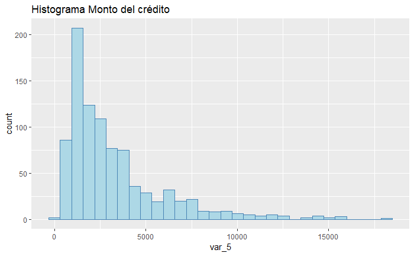

```r
ggplot(data_desafio_seguros, aes(x=var_5))+
  geom_histogram(color="steelblue", fill="lightblue")+ggtitle("Histograma Monto del crédito ")
```

### Variable 13: Edad en años

```r
describe(data_desafio_seguros$var_13)
```

```
data_desafio_seguros$var_13
       n  missing distinct     Info     Mean      Gmd      .05      .10      .25      .50      .75      .90      .95
     900        0       53    0.999    35.57    12.45       22       23       27       33       42       52       60

lowest : 19 20 21 22 23, highest: 67 68 70 74 75
```

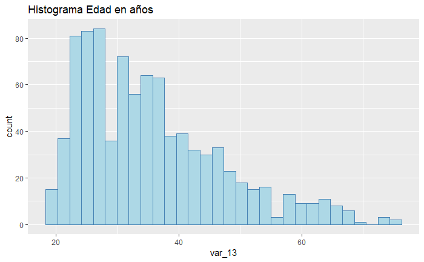

```r
ggplot(data_desafio_seguros, aes(x=var_13))+
  geom_histogram(color="steelblue", fill="lightblue")+ggtitle("Histograma Edad en años")
```

### Variable 1: Estado de cuenta corriente existente

```r
#Variables cualitativas#
describe(data_desafio_seguros$var_1)
```

```
data_desafio_seguros$var_1
       n  missing distinct
     900        0        4

Value        A11   A12   A13   A14
Frequency    243   242    61   354
Proportion 0.270 0.269 0.068 0.393
```

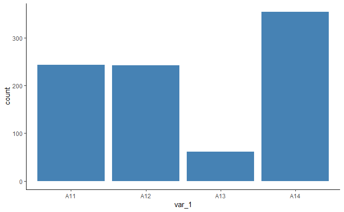

```r
ggplot(data_desafio_seguros, aes(var_1)) +
  geom_bar(fill="steelblue", width = NULL) + theme_classic()
```

### Variable 3: Historia crediticia

```r
describe(data_desafio_seguros$var_3)
```

```
data_desafio_seguros$var_3
       n  missing distinct
     900        0        5

Value        A30   A31   A32   A33   A34
Frequency     32    46   472    84   266
Proportion 0.036 0.051 0.524 0.093 0.296
```

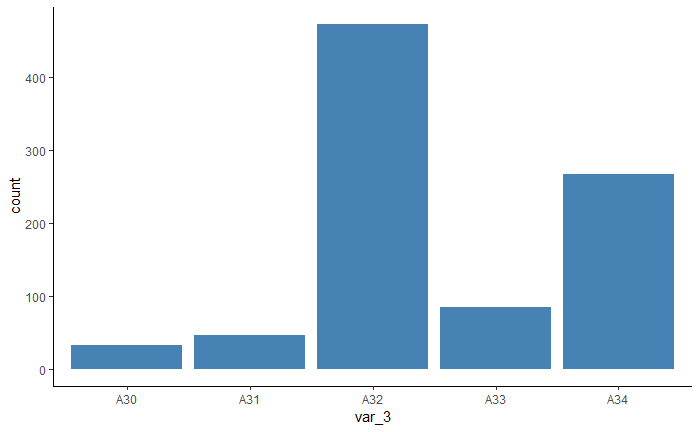

```r
ggplot(data_desafio_seguros, aes(var_3)) +
  geom_bar(fill="steelblue", width = NULL) + theme_classic()
```

### Variable 4: Propósito del crédito

```r
describe(data_desafio_seguros$var_4)
```

```
data_desafio_seguros$var_4
       n  missing distinct
     900        0       10

Value        A40   A41  A410   A42   A43   A44   A45   A46   A48   A49
Frequency    214    93    11   169   246     9    18    45     8    87
Proportion 0.238 0.103 0.012 0.188 0.273 0.010 0.020 0.050 0.009 0.097
```

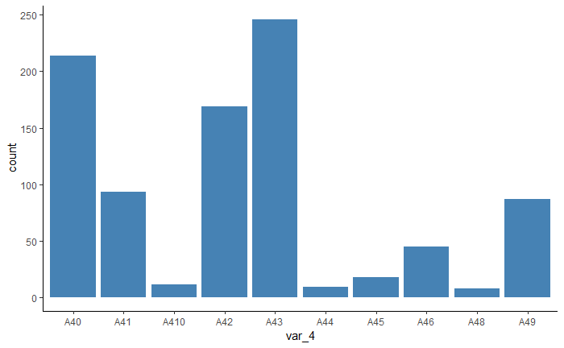

```r
ggplot(data_desafio_seguros, aes(var_4)) +
  geom_bar(fill="steelblue", width = NULL) + theme_classic()
```

### Variable 6: Ahorros en la cuenta

```r
describe(data_desafio_seguros$var_6)
```

```
data_desafio_seguros$var_6
       n  missing distinct
     900        0        5

Value        A61   A62   A63   A64   A65
Frequency    538    94    60    43   165
Proportion 0.598 0.104 0.067 0.048 0.183
```

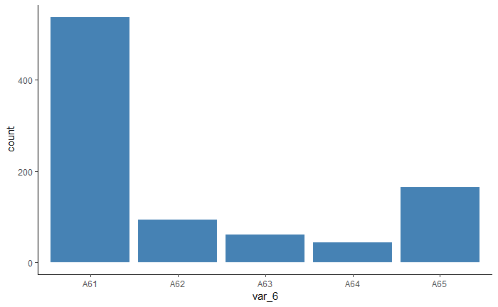

```r
ggplot(data_desafio_seguros, aes(var_6)) +
  geom_bar(fill="steelblue", width = NULL) + theme_classic()
```

### Variable 7: Tiempo en el empleo actual

```r
describe(data_desafio_seguros$var_7)
```

```
data_desafio_seguros$var_7
       n  missing distinct
     900        0        5

Value        A71   A72   A73   A74   A75
Frequency     57   151   309   155   228
Proportion 0.063 0.168 0.343 0.172 0.253
```

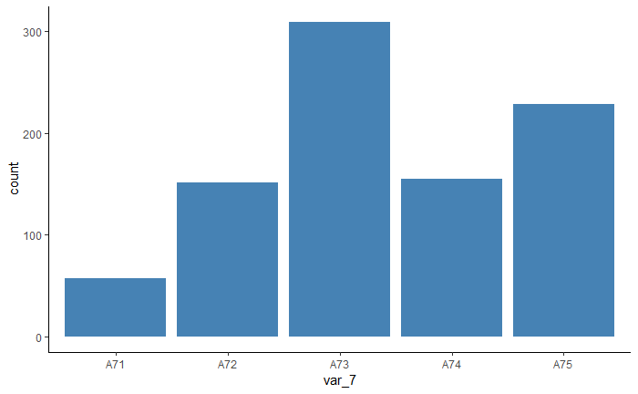

```r
ggplot(data_desafio_seguros, aes(var_7)) +
  geom_bar(fill="steelblue", width = NULL) + theme_classic()
```

### Variable 8: Tasa a plazo en porcentaje de la renta disponible

```r
describe(data_desafio_seguros$var_8)
```

```
data_desafio_seguros$var_8
       n  missing distinct     Info     Mean      Gmd
     900        0        4    0.872    2.976    1.196

Value          1     2     3     4
Frequency    119   214   137   430
Proportion 0.132 0.238 0.152 0.478
```

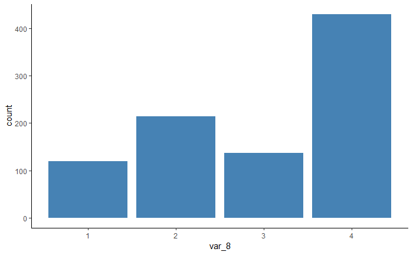

```r
ggplot(data_desafio_seguros, aes(var_8)) +
  geom_bar(fill="steelblue", width = NULL) + theme_classic()
```

### Variable 9: Estatus y sexo

```r
describe(data_desafio_seguros$var_9)
```

```
data_desafio_seguros$var_9
       n  missing distinct
     900        0        4

Value        A91   A92   A93   A94
Frequency     47   273   494    86
Proportion 0.052 0.303 0.549 0.096
```

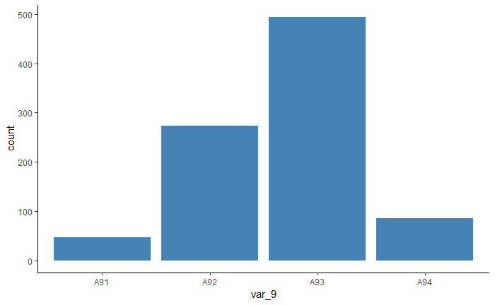

```r
ggplot(data_desafio_seguros, aes(var_9)) +
  geom_bar(fill="steelblue", width = NULL) + theme_classic()
```

### Variable 10: Otros deudores y garantes

```r
describe(data_desafio_seguros$var_10)
```

```
data_desafio_seguros$var_10
       n  missing distinct
     900        0        3

Value       A101  A102  A103
Frequency    820    37    43
Proportion 0.911 0.041 0.048
```

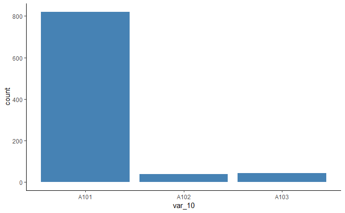

```r
ggplot(data_desafio_seguros, aes(var_10)) +
  geom_bar(fill="steelblue", width = NULL) + theme_classic()
```

### Variable 11: Tiempo desde el cual tiene residencia

```r
describe(data_desafio_seguros$var_11)
```

```
data_desafio_seguros$var_11
       n  missing distinct     Info     Mean      Gmd
     900        0        4    0.895     2.85    1.195

Value          1     2     3     4
Frequency    112   281   137   370
Proportion 0.124 0.312 0.152 0.411
```

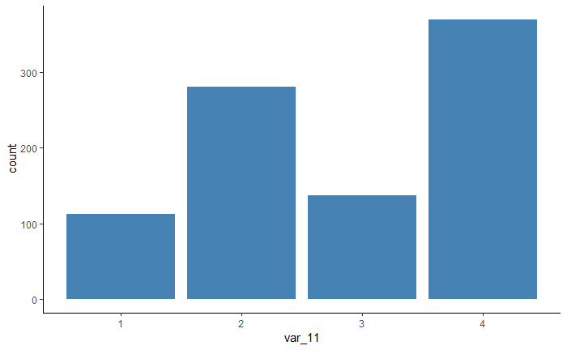

```r
ggplot(data_desafio_seguros, aes(var_11)) +
  geom_bar(fill="steelblue", width = NULL) + theme_classic()
```

### Variable 12: Posesiones a su nombre

```r
describe(data_desafio_seguros$var_12)
```

```
data_desafio_seguros$var_12
       n  missing distinct
     900        0        4

Value       A121  A122  A123  A124
Frequency    251   214   298   137
Proportion 0.279 0.238 0.331 0.152
```

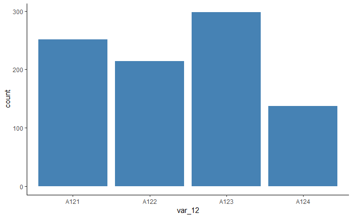

```r
ggplot(data_desafio_seguros, aes(var_12)) +
  geom_bar(fill="steelblue", width = NULL) + theme_classic()
```

### Variable 14: Otros pagos pendientes en cuotas

```r
describe(data_desafio_seguros$var_14)
```

```
data_desafio_seguros$var_14
       n  missing distinct
     900        0        3

Value       A141  A142  A143
Frequency    128    42   730
Proportion 0.142 0.047 0.811
```

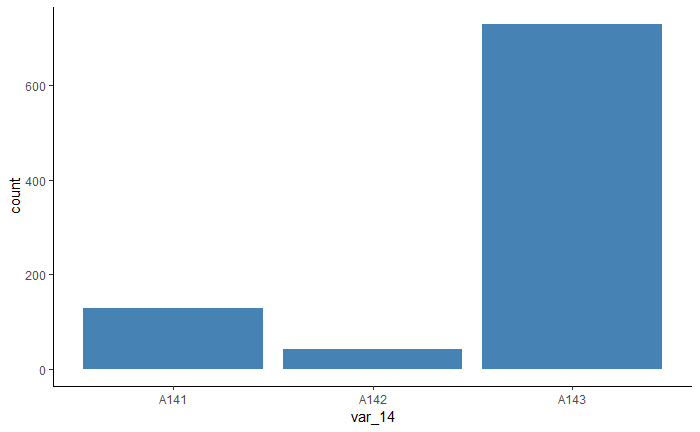

```r
ggplot(data_desafio_seguros, aes(var_14)) +
  geom_bar(fill="steelblue", width = NULL) + theme_classic()
```

### Variable 15: Forma en la que vive

```r
describe(data_desafio_seguros$var_15)
```

```
data_desafio_seguros$var_15
       n  missing distinct
     900        0        3

Value       A151  A152  A153
Frequency    162   640    98
Proportion 0.180 0.711 0.109
```

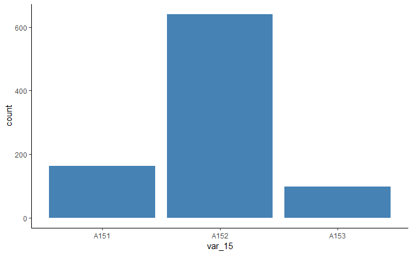

```r
ggplot(data_desafio_seguros, aes(var_15)) +
  geom_bar(fill="steelblue", width = NULL) + theme_classic()
```

### Variable 16: Número de créditos existentes en este banco actualmente

```r
describe(data_desafio_seguros$var_16)
```

```
data_desafio_seguros$var_16
       n  missing distinct     Info     Mean      Gmd
     900        0        4    0.706    1.398   0.5273

Value          1     2     3     4
Frequency    571   304    21     4
Proportion 0.634 0.338 0.023 0.004
```

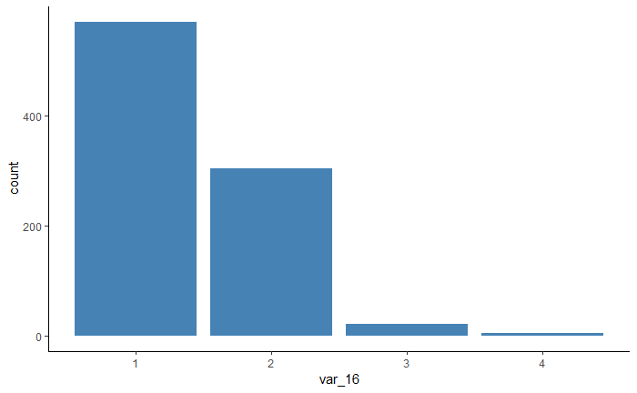

```r
ggplot(data_desafio_seguros, aes(var_16)) +
  geom_bar(fill="steelblue", width = NULL) + theme_classic()
```

### Variable 17: Tipo de trabajo

```r
describe(data_desafio_seguros$var_17)
```

```
data_desafio_seguros$var_17
       n  missing distinct
     900        0        4

Value       A171  A172  A173  A174
Frequency     19   180   569   132
Proportion 0.021 0.200 0.632 0.147
```

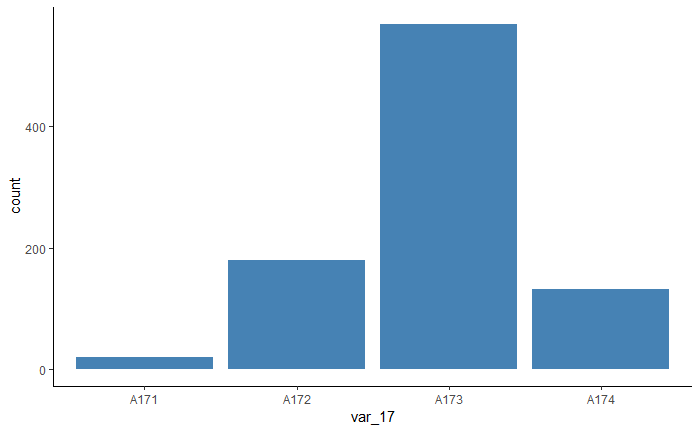

```r
ggplot(data_desafio_seguros, aes(var_17)) +
  geom_bar(fill="steelblue", width = NULL) + theme_classic()
```

### Variable 18: Número de personas por las cuales es responsable de dar mantenimiento

```r
describe(data_desafio_seguros$var_18)
```

```
data_desafio_seguros$var_18
       n  missing distinct     Info     Mean      Gmd
     900        0        2    0.378    1.148   0.2522

Value          1     2
Frequency    767   133
Proportion 0.852 0.148
```

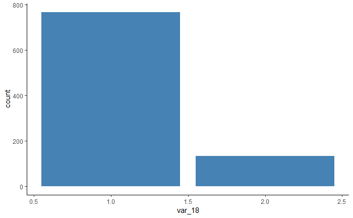

```r
ggplot(data_desafio_seguros, aes(var_18)) +
  geom_bar(fill="steelblue", width = NULL) + theme_classic()
```

### Variable 19: Si tiene teléfono

```r
describe(data_desafio_seguros$var_19)
```

```
data_desafio_seguros$var_19
       n  missing distinct
     900        0        2

Value      A191 A192
Frequency   531  369
Proportion 0.59 0.41
```

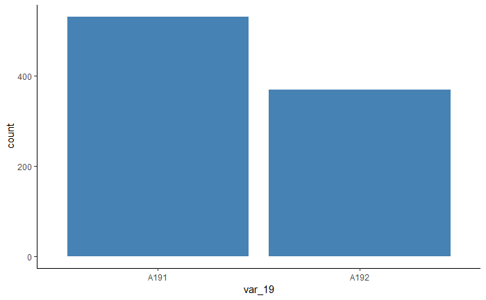

```r
ggplot(data_desafio_seguros, aes(var_19)) +
  geom_bar(fill="steelblue", width = NULL) + theme_classic()
```

### Variable 20: Si es un trabajador extranjero

```r
describe(data_desafio_seguros$var_20)
```

```
data_desafio_seguros$var_20
       n  missing distinct
     900        0        2

Value       A201  A202
Frequency    865    35
Proportion 0.961 0.039
```

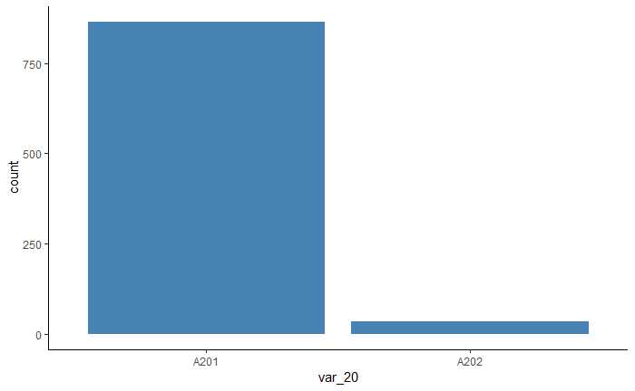

```r
ggplot(data_desafio_seguros, aes(var_20)) +
  geom_bar(fill="steelblue", width = NULL) + theme_classic()
```

### Variable 21: Clasificación actual

```r
describe(data_desafio_seguros$var_21)
```

```
data_desafio_seguros$var_21
       n  missing distinct
     900        0        2

Value          1     2
Frequency    632   268
Proportion 0.702 0.298
```

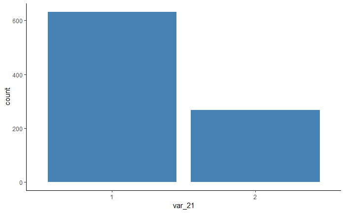

```r
ggplot(data_desafio_seguros, aes(var_21)) +
  geom_bar(fill="steelblue", width = NULL) + theme_classic()
```

# Estadística descriptiva bivariada.

### Variable 21: Clasificación actual

```r
attach(data_desafio_seguros)

table(var_21,var_21)
```

```
      var_21
var_21   1   2
     1 632   0
     2   0 268
```

```r
prop.table(table(var_21,var_21))
```

```
      var_21
var_21         1         2
     1 0.7022222 0.0000000
     2 0.0000000 0.2977778
```

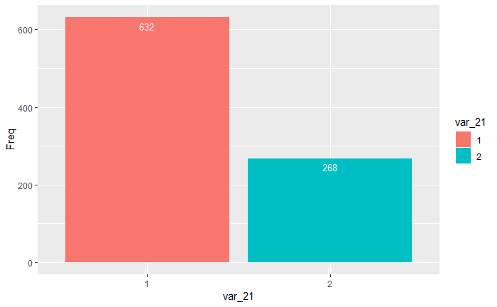

```r
ggplot(data=as.data.frame(table(var_21,var_21)), aes(x=var_21, y=Freq, fill=var_21)) +
  geom_bar(stat="identity", position=position_dodge())+
  geom_text(aes(label=Freq), vjust=1.6, color="white", position = position_dodge(0.9),size=3.5)
```

```r
detach(data_desafio_seguros)
```

### Variable 2: Duración en meses

```r
group_by(data_desafio_seguros, var_21) %>%
  summarise(n = n(), min_var2= min(var_2) , p10 = quantile(var_2, probs = 0.1), p25 = quantile(var_2, probs = 0.25),mean_var5=mean(var_2), median_var2=median(var_2), p75 = quantile(var_2, probs = 0.75), p90 = quantile(var_2, probs = 0.9), p99 = quantile(var_2, probs = 0.99), max_var2 = max(var_2),sd=sd(var_2))
```

| var_21 | n | min_var2 | p10 | p25 | mean_var5 | median_var2 | p75 | p90 | p99 | max_var2 | sd |
| --- | --- | --- | --- | --- | --- | --- | --- | --- | --- | --- | --- |
| 1 | 632 | 4 | 6.1 | 12 | 19.47152 | 18 | 24 | 36 | 58.14 | 60 | 11.17428 |
| 2 | 268 | 6 | 12.0 | 12 | 24.91791 | 24 | 36 | 48 | 60.00 | 72 | 13.24816 |

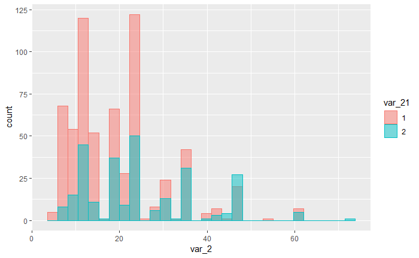

```r
ggplot(data_desafio_seguros, aes(x=var_2, fill=var_21, color=var_21)) +
  geom_histogram(position="identity", alpha=0.5)
```

### Variable 5:

```r
group_by(data_desafio_seguros, var_21) %>%
  summarise(n = n(), min_var5= min(var_5) , p10 = quantile(var_5, probs = 0.1), p25 = quantile(var_5, probs = 0.25),mean_var5=mean(var_5), median_var5=median(var_5), p75 = quantile(var_5, probs = 0.75), p90 = quantile(var_5, probs = 0.9), p99 = quantile(var_5, probs = 0.99), max_var5 = max(var_5),sd=sd(var_5))
```

| var_21 | n | min_var5 | p10 | p25 | mean_var5 | median_var5 | p75 | p90 | p99 | max_var5 | sd |
| --- | --- | --- | --- | --- | --- | --- | --- | --- | --- | --- | --- |
| 1 | 632 | 250 | 996.3 | 1393.00 | 3015.003 | 2264 | 3664.0 | 6302.5 | 12042.21 | 15857 | 2399.412 |
| 2 | 268 | 433 | 917.1 | 1357.25 | 3892.015 | 2590 | 5141.5 | 8464.6 | 14819.62 | 18424 | 3438.114 |

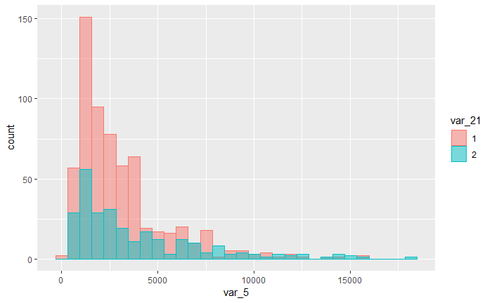

```r
ggplot(data_desafio_seguros, aes(x=var_5, fill=var_21, color=var_21)) +
  geom_histogram(position="identity", alpha=0.5)
```

### Variable 13:

```r
group_by(data_desafio_seguros, var_21) %>%
  summarise(n = n(), min_var13= min(var_13) , p10 = quantile(var_13, probs = 0.1), p25 = quantile(var_13, probs = 0.25),mean_var13=mean(var_13), median_var13=median(var_13), p75 = quantile(var_13, probs = 0.75), p90 = quantile(var_13, probs = 0.9), p99 = quantile(var_13, probs = 0.99), max_var13 = max(var_13),sd=sd(var_13))
```

| var_21 | n | min_var13 | p10 | p25 | mean_var13 | median_var13 | p75 | p90 | p99 | max_var13 | sd |
| --- | --- | --- | --- | --- | --- | --- | --- | --- | --- | --- | --- |
| 1 | 632 | 19 | 24 | 27 | 36.25949 | 34 | 43 | 52.0 | 67.00 | 75 | 11.35841 |
| 2 | 268 | 19 | 23 | 25 | 33.93657 | 30 | 40 | 51.3 | 66.66 | 74 | 11.34906 |

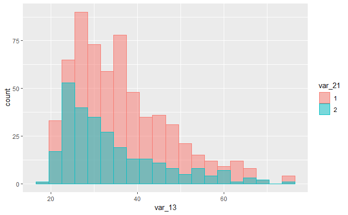

```r
ggplot(data_desafio_seguros, aes(x=var_13, fill=var_21, color=var_21)) +
  geom_histogram(position="identity", alpha=0.5, binwidth=3)
```

### Variable 1:

```r
table(var_21,var_1)
```

```
      var_1
var_21 A11 A12 A13 A14
     1 124 149  47 312
     2 119  93  14  42
```

```r
as.table(prop.table(table(var_21,var_1)))
```

```
      var_1
var_21        A11        A12        A13        A14
     1 0.13777778 0.16555556 0.05222222 0.34666667
     2 0.13222222 0.10333333 0.01555556 0.04666667
```

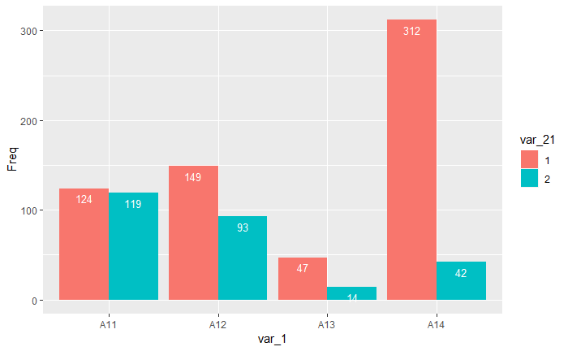

```r
ggplot(data=as.data.frame(table(var_21,var_1)), aes(x=var_1, y=Freq, fill=var_21)) +
  geom_bar(stat="identity", position=position_dodge())+
  geom_text(aes(label=Freq), vjust=1.6, color="white", position = position_dodge(0.9),size=3.5)
```

### Variable 3:

```r
table(var_21,var_3)
```

```
      var_3
var_21 A30 A31 A32 A33 A34
     1  11  20 323  57 221
     2  21  26 149  27  45
```

```r
prop.table(table(var_21,var_3))
```

```
      var_3
var_21        A30        A31        A32        A33        A34
     1 0.01222222 0.02222222 0.35888889 0.06333333 0.24555556
     2 0.02333333 0.02888889 0.16555556 0.03000000 0.05000000
```

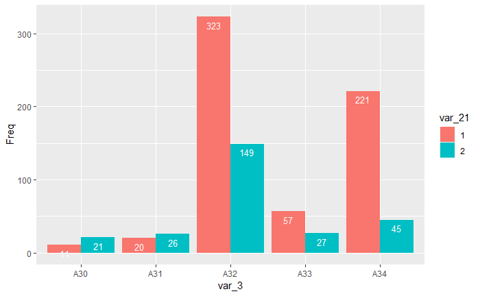

```r
ggplot(data=as.data.frame(table(var_21,var_3)), aes(x=var_3, y=Freq, fill=var_21)) +
  geom_bar(stat="identity", position=position_dodge())+
  geom_text(aes(label=Freq), vjust=1.6, color="white", position = position_dodge(0.9),size=3.5)
```

### Variable 4:

```r
table(var_21,var_4)
```

```
      var_4
var_21 A40 A41 A410 A42 A43 A44 A45 A46 A48 A49
     1 133  78    7 114 192   6  13  24   8  57
     2  81  15    4  55  54   3   5  21   0  30
```

```r
prop.table(table(var_21,var_4))
```

```
      var_4
var_21         A40         A41        A410         A42         A43         A44         A45         A46         A48         A49
     1 0.147777778 0.086666667 0.007777778 0.126666667 0.213333333 0.006666667 0.014444444 0.026666667 0.008888889 0.063333333
     2 0.090000000 0.016666667 0.004444444 0.061111111 0.060000000 0.003333333 0.005555556 0.023333333 0.000000000 0.033333333
```

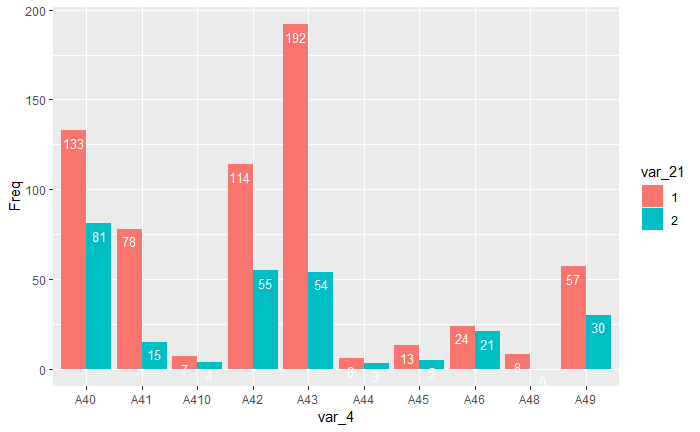

```r
ggplot(data=as.data.frame(table(var_21,var_4)), aes(x=var_4, y=Freq, fill=var_21)) +
  geom_bar(stat="identity", position=position_dodge())+
  geom_text(aes(label=Freq), vjust=1.6, color="white", position = position_dodge(0.9),size=3.5)
```

### Variable 7:

```r
table(var_21,var_7)
```

```
      var_7
var_21 A71 A72 A73 A74 A75
     1  37  90 214 121 170
     2  20  61  95  34  58
```

```r
prop.table(table(var_21,var_7))
```

```
      var_7
var_21        A71        A72        A73        A74        A75
     1 0.04111111 0.10000000 0.23777778 0.13444444 0.18888889
     2 0.02222222 0.06777778 0.10555556 0.03777778 0.06444444
```

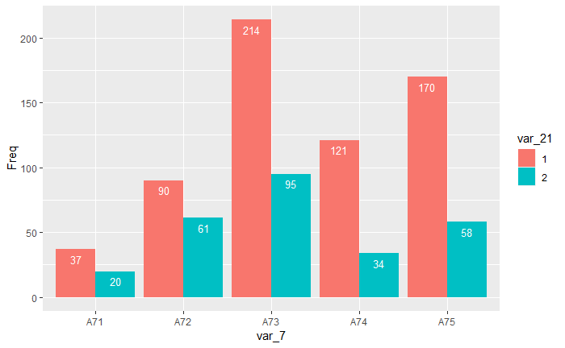

```r
ggplot(data=as.data.frame(table(var_21,var_7)), aes(x=var_7, y=Freq, fill=var_21)) +
  geom_bar(stat="identity", position=position_dodge())+
  geom_text(aes(label=Freq), vjust=1.6, color="white", position = position_dodge(0.9),size=3.5)
```

### Variable 8:

```r
table(var_21,var_8)
```

```
      var_8
var_21   1   2   3   4
     1  91 157  95 289
     2  28  57  42 141
```

```r
prop.table(table(var_21,var_8))
```

```
      var_8
var_21          1          2          3          4
     1 0.10111111 0.17444444 0.10555556 0.32111111
     2 0.03111111 0.06333333 0.04666667 0.15666667
```

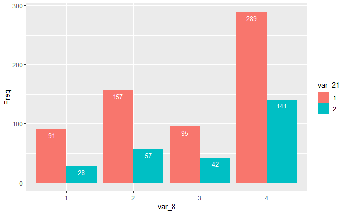

```r
ggplot(data=as.data.frame(table(var_21,var_8)), aes(x=var_8, y=Freq, fill=var_21)) +
  geom_bar(stat="identity", position=position_dodge())+
  geom_text(aes(label=Freq), vjust=1.6, color="white", position = position_dodge(0.9),size=3.5)
```

### Variable 9:

```r
table(var_21,var_9)
```

```
      var_9
var_21 A91 A92 A93 A94
     1  28 175 367  62
     2  19  98 127  24
```

```r
prop.table(table(var_21,var_9))
```

```
      var_9
var_21        A91        A92        A93        A94
     1 0.03111111 0.19444444 0.40777778 0.06888889
     2 0.02111111 0.10888889 0.14111111 0.02666667
```

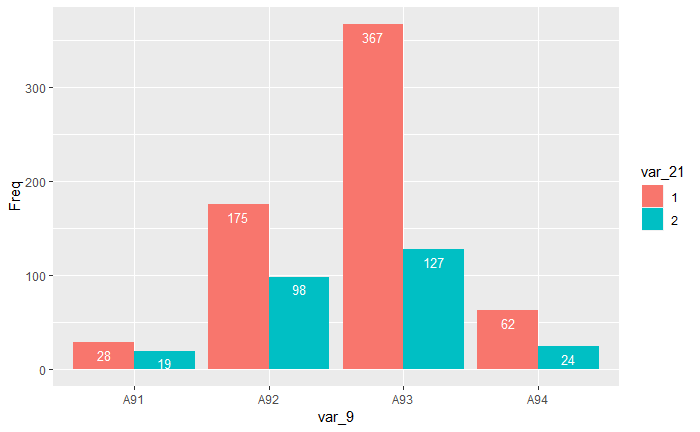

```r
ggplot(data=as.data.frame(table(var_21,var_9)), aes(x=var_9, y=Freq, fill=var_21)) +
  geom_bar(stat="identity", position=position_dodge())+
  geom_text(aes(label=Freq), vjust=1.6, color="white", position = position_dodge(0.9),size=3.5)
```